# Python-for-Web-11

**Principle of Rest API**

- The term *representational state transfer* was introduced and defined in 2000 by computer scientist Roy Fielding in his doctoral dissertation.
- It means that a server will respond with the representation of a resource (today, it will most often be an "HTML", XML or JSON document)
- Further, that resource will contain hypermedia links that can be followed to make the state of the system change.
- Any such request will in turn receive the representation of a resource, and so on.
- An important consequence is that the **only identifier that needs to be known is the identifier of the first resource requested**, and all other identifiers will be discovered.
- This means that those identifiers can change without the need to inform the client beforehand and that there can be only loose coupling between client and server.
- So Rest API concepts are different from those of some APIs, such as **`SOAP`** or **`XML-RPC`**, impose a strict framework on developers.
- **SOAP** and **REST** are two different approaches to API design. The SOAP approach is highly structured and uses XML data format. REST is more flexible and allows applications to exchange data in multiple formats.
- So Rest API concepts are different from those of some APIs, such as **`SOAP`** or **`XML-RPC`**, impose a strict framework on developers.
- **SOAP** and **REST** are two different approaches to API design. The SOAP approach is highly structured and uses XML data format. REST is more flexible and allows applications to exchange data in multiple formats.

**We should enter a REST API with no prior knowledge beyond the initial URI**

- We should enter a REST API with no prior knowledge beyond
  - the initial URI (a bookmark) and
  - a set of standardized media types appropriate for the intended audience (i.e., expected to be understood by any client that might use the API).

From that point on, all application state transitions must be driven by the client selection of server-provided choices present in the received representations or implied by the user’s manipulation of those representations.

The transitions may be determined (or limited by) the client’s knowledge of media types and resource communication mechanisms, both of which may be improved on the fly (e.g., *code-on-demand*). [Failure here implies that out-of-band information is driving interaction instead of hypertext.]

**REST API**

Some APIs, such as `SOAP` or `XML-RPC`, impose a strict framework on developers. But REST APIs can be developed using virtually any programming language and support a variety of data formats. The only requirement is that they align to the following six REST design principles - also known as architectural constraints:

1. **Uniform interface**. All API requests for the same resource should look the same, no matter where the request comes from. The REST API should ensure that the same piece of data, such as the name or email address of a user, belongs to only one uniform resource identifier (URI). Resources shouldn’t be too large but should contain every piece of information that the client might need.
2. **Client-server decoupling**. In REST API design, client and server applications must be completely independent of each other. The only information the client application should know is the URI of the requested resource; it can't interact with the server application in any other ways. Similarly, a server application shouldn't modify the client application other than passing it to the requested data via HTTP.
3. **Statelessness**. REST APIs are stateless, meaning that each request needs to include all the information necessary for processing it. In other words, REST APIs do not require any server-side sessions. Server applications aren’t allowed to store any data related to a client request.
4. **Cacheability**. When possible, resources should be cacheable on the client or server side. Server responses also need to contain information about whether caching is allowed for the delivered resource. The goal is to improve performance on the client side, while increasing scalability on the server side.
5. **Layered system architecture**. In REST APIs, the calls and responses go through different layers. As a rule of thumb, don’t assume that the client and server applications connect directly to each other. There may be a number of different intermediaries in the communication loop. REST APIs need to be designed so that neither the client nor the server can tell whether it communicates with the end application or an intermediary.
6. **Code on demand (optional)**. REST APIs usually send static resources, but in certain cases, responses can also contain executable code (such as Java applets). In these cases, the code should only run on-demand.

**How REST APIs work**

REST APIs communicate via HTTP requests to perform standard database functions like creating, reading, updating, and deleting records (also known as CRUD) within a resource. For example, a REST API would use a

- a GET request to retrieve a record,
- a POST request to create one,
- a PUT request to update a record, and
- a DELETE request to delete one.

All HTTP methods can be used in API calls. A well-designed REST API is similar to a website running in a web browser with built-in HTTP functionality.

- The state of a resource at any particular instant, or timestamp, is known as the resource representation.
- This information can be delivered to a client in virtually any format including JavaScript Object Notation (JSON), HTML, XLT, Python, PHP, or plain text.
- JSON is popular because it’s readable by both humans and machines—and it is programming language-agnostic.

**Request headers and parameters**

Request headers and parameters are also important in REST API calls because they include important identifier information such as metadata, authorizations, uniform resource identifiers (URIs), caching, cookies and more. Request headers and response headers, along with conventional HTTP status codes, are used within well-designed REST APIs.

**OpenAPI Specification (OAS)**

The OpenAPI Specification (OAS) establishes an interface for describing an API in a way that allows any developer or application to discover it and fully understand its parameters and capabilities - available endpoints, allowed operations on each endpoint, operation parameters, authentication methods, and other information. The latest version, [OAS3](https://github.com/OAI/OpenAPI-Specification/blob/main/versions/3.0.2.md) includes with hands-on tools, such as the OpenAPI Generator, for generating API clients and server stubs in different programming languages.

**What is a Resource?**

The key **abstraction of information** in REST is a [resource](https://restfulapi.net/resource-naming/). Any information that we can name can be a resource. For example, a REST resource can be a document or image, a temporal service, a collection of other resources, or a non-virtual object (e.g., a person).

The state of the resource, at any particular time, is known as the **resource representation**.

The resource representations are consist of:

- the **data**
- the **metadata** describing the data
- and the **hypermedia links** that can help the clients in transition to the next desired state.

A REST API consists of an assembly of interlinked resources. This set of resources is known as the REST API’s **resource model**.

**HTTP Messages**

- HTTP messages are how data is exchanged between a server and a client. There are two types of messages: *`requests`* sent by the client to trigger an action on the server, and *`responses`*, the answer from the server.
- HTTP messages are composed of textual information encoded in ASCII, and span over multiple lines. In HTTP/1.1, and earlier versions of the protocol, these messages were openly sent across the connection.
- In HTTP/2, the once human-readable message is now divided up into HTTP frames, providing optimization and performance improvements.
- Web developers, or webmasters, rarely craft these textual HTTP messages themselves: software, a Web browser, proxy, or Web server, perform this action. They provide HTTP messages through config files (for proxies or servers), APIs (for browsers), or other interfaces.

HTTP requests, and responses, share similar structure and are composed of:

1. A *start-line* describing the requests to be implemented, or its status of whether successful or a failure. This start-line is always a single line.
2. An optional set of *HTTP headers* specifying the request, or describing the body included in the message.
3. A blank line indicating all meta-information for the request has been sent.
4. An optional *body* containing data associated with the request (like content of an HTML form), or the document associated with a response. The presence of the body and its size is specified by the start-line and HTTP headers.

The start-line and HTTP headers of the HTTP message are collectively known as the *head* of the requests, whereas its payload is known as the *body*.

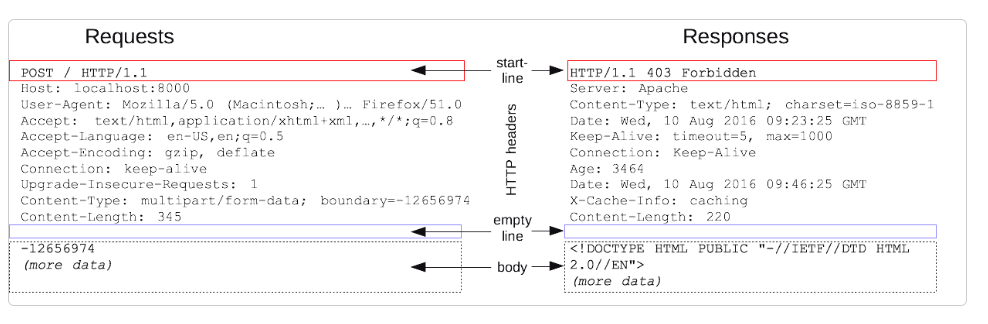

[Taken from developer.mozilla.org](https://developer.mozilla.org/en-US/docs/Web/HTTP/Messages)

**Note:-**

- The first line is always the start line with a fixed number of positional arguments (`HTTP` method, request url/path, `HTTP` version) delimited by whitespace.
- Each following line is a `Name: Value` header pair until an eventual empty line.
- If there is a`Content-Length` header, then after the empty line you must also expect a message body of the specified length.

## [HTTP Requests](https://developer.mozilla.org/en-US/docs/Web/HTTP/Messages#http_requests)

### [Start line](https://developer.mozilla.org/en-US/docs/Web/HTTP/Messages#start_line)

HTTP requests are messages sent by the client to initiate an action on the server. Their *start-line* contain three elements:

1. An *[HTTP method](https://developer.mozilla.org/en-US/docs/Web/HTTP/Methods)*, a verb (like [`GET`](https://developer.mozilla.org/en-US/docs/Web/HTTP/Methods/GET), [`PUT`](https://developer.mozilla.org/en-US/docs/Web/HTTP/Methods/PUT) or [`POST`](https://developer.mozilla.org/en-US/docs/Web/HTTP/Methods/POST)) or a noun (like [`HEAD`](https://developer.mozilla.org/en-US/docs/Web/HTTP/Methods/HEAD) or [`OPTIONS`](https://developer.mozilla.org/en-US/docs/Web/HTTP/Methods/OPTIONS)), that describes the action to be performed. For example, `GET` indicates that a resource should be fetched or `POST` means that data is pushed to the server (creating or modifying a resource, or generating a temporary document to send back).
2. The *request target*, usually a URL, or the absolute path of the protocol, port, and domain are usually characterized by the request context. The format of this request target varies between different HTTP methods. It can be
   - An absolute path, ultimately followed by a `'?'` and query string. This is the most common form, known as the *origin form*, and is used with `GET`, `POST`, `HEAD`, and `OPTIONS` methods.
     - `POST / HTTP/1.1`
     - `GET /background.png HTTP/1.0`
     - `HEAD /test.html?query=alibaba HTTP/1.1`
     - `OPTIONS /anypage.html HTTP/1.0`
   - A complete URL, known as the *absolute form*, is mostly used with `GET` when connected to a proxy. `GET https://developer.mozilla.org/en-US/docs/Web/HTTP/Messages HTTP/1.1`
   - The authority component of a URL, consisting of the domain name and optionally the port (prefixed by a `':'`), is called the *authority form*. It is only used with `CONNECT` when setting up an HTTP tunnel. `CONNECT developer.mozilla.org:80 HTTP/1.1`
   - The *asterisk form*, a simple asterisk (`'*'`) is used with `OPTIONS`, representing the server as a whole. `OPTIONS * HTTP/1.1`
3. The *HTTP version*, which defines the structure of the remaining message, acting as an indicator of the expected version to use for the response.

### [Headers](https://developer.mozilla.org/en-US/docs/Web/HTTP/Messages#headers)

[HTTP headers](https://developer.mozilla.org/en-US/docs/Web/HTTP/Headers) from a request follow the same basic structure of an HTTP header: a case-insensitive string followed by a colon (`':'`) and a value whose structure depends upon the header. The whole header, including the value, consists of one single line, which can be quite long.

Many different headers can appear in requests. They can be divided in several groups:

- [General headers](https://developer.mozilla.org/en-US/docs/Glossary/General_header), like [`Via`](https://developer.mozilla.org/en-US/docs/Web/HTTP/Headers/Via), apply to the message as a whole.
- [Request headers](https://developer.mozilla.org/en-US/docs/Glossary/Request_header), like [`User-Agent`](https://developer.mozilla.org/en-US/docs/Web/HTTP/Headers/User-Agent) or [`Accept`](https://developer.mozilla.org/en-US/docs/Web/HTTP/Headers/Accept), modify the request by specifying it further (like [`Accept-Language`](https://developer.mozilla.org/en-US/docs/Web/HTTP/Headers/Accept-Language)), by giving context (like [`Referer`](https://developer.mozilla.org/en-US/docs/Web/HTTP/Headers/Referer)), or by conditionally restricting it (like [`If-None`](https://developer.mozilla.org/en-US/docs/Web/HTTP/Headers/If-None)).
- [Representation headers](https://developer.mozilla.org/en-US/docs/Glossary/Representation_header) like [`Content-Type`](https://developer.mozilla.org/en-US/docs/Web/HTTP/Headers/Content-Type) that describe the original format of the message data and any encoding applied (only present if the message has a body).

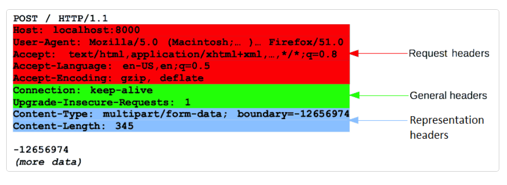

### [Body](https://developer.mozilla.org/en-US/docs/Web/HTTP/Messages#body)

The final part of the request is its body. Not all requests have one: requests fetching resources, like `GET`, `HEAD`, `DELETE`, or `OPTIONS`, usually don't need one. Some requests send data to the server in order to update it: as often the case with `POST` requests (containing HTML form data).

Bodies can be broadly divided into two categories:

- Single-resource bodies, consisting of one single file, defined by the two headers: [`Content-Type`](https://developer.mozilla.org/en-US/docs/Web/HTTP/Headers/Content-Type) and [`Content-Length`](https://developer.mozilla.org/en-US/docs/Web/HTTP/Headers/Content-Length).
- [Multiple-resource bodies](https://developer.mozilla.org/en-US/docs/Web/HTTP/Basics_of_HTTP/MIME_types#multipartform-data), consisting of a multipart body, each containing a different bit of information. This is typically associated with [HTML Forms](https://developer.mozilla.org/en-US/docs/Learn/Forms).

## [HTTP Responses](https://developer.mozilla.org/en-US/docs/Web/HTTP/Messages#http_responses)

### [Status line](https://developer.mozilla.org/en-US/docs/Web/HTTP/Messages#status_line)

The start line of an HTTP response, called the *status line*, contains the following information:

1. The *protocol version*, usually `HTTP/1.1`.
2. A *status code*, indicating success or failure of the request. Common status codes are [`200`](https://developer.mozilla.org/en-US/docs/Web/HTTP/Status/200), [`404`](https://developer.mozilla.org/en-US/docs/Web/HTTP/Status/404), or [`302`](https://developer.mozilla.org/en-US/docs/Web/HTTP/Status/302)
3. A *status text*. A brief, purely informational, textual description of the status code to help a human understand the HTTP message.

A typical status line looks like: `HTTP/1.1 404 Not Found`.

### [Headers](https://developer.mozilla.org/en-US/docs/Web/HTTP/Messages#headers_2)

[HTTP headers](https://developer.mozilla.org/en-US/docs/Web/HTTP/Headers) for responses follow the same structure as any other header: a case-insensitive string followed by a colon (`':'`) and a value whose structure depends upon the type of the header. The whole header, including its value, presents as a single line.

Many different headers can appear in responses. These can be divided into several groups:

- [General headers](https://developer.mozilla.org/en-US/docs/Glossary/General_header), like [`Via`](https://developer.mozilla.org/en-US/docs/Web/HTTP/Headers/Via), apply to the whole message.
- [Response headers](https://developer.mozilla.org/en-US/docs/Glossary/Response_header), like [`Vary`](https://developer.mozilla.org/en-US/docs/Web/HTTP/Headers/Vary) and [`Accept-Ranges`](https://developer.mozilla.org/en-US/docs/Web/HTTP/Headers/Accept-Ranges), give additional information about the server which doesn't fit in the status line.
- [Representation headers](https://developer.mozilla.org/en-US/docs/Glossary/Representation_header) like [`Content-Type`](https://developer.mozilla.org/en-US/docs/Web/HTTP/Headers/Content-Type) that describe the original format of the message data and any encoding applied (only present if the message has a body).

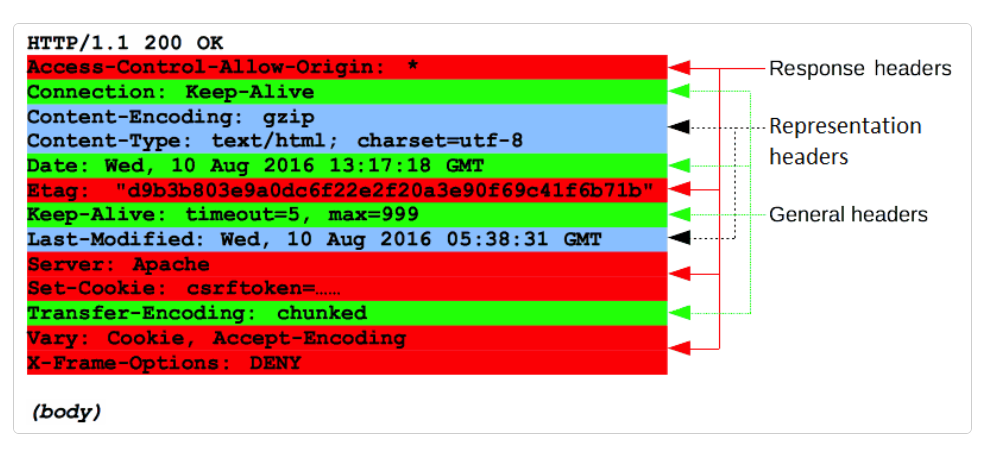

### [Body](https://developer.mozilla.org/en-US/docs/Web/HTTP/Messages#body_2)

The last part of a response is the body. Not all responses have one: responses with a status code that sufficiently answers the request without the need for corresponding payload (like [`201`](https://developer.mozilla.org/en-US/docs/Web/HTTP/Status/201) **`Created`** or [`204`](https://developer.mozilla.org/en-US/docs/Web/HTTP/Status/204) **`No Content`**) usually don't.

Bodies can be broadly divided into three categories:

- Single-resource bodies, consisting of a single file of known length, defined by the two headers: [`Content-Type`](https://developer.mozilla.org/en-US/docs/Web/HTTP/Headers/Content-Type) and [`Content-Length`](https://developer.mozilla.org/en-US/docs/Web/HTTP/Headers/Content-Length).
- Single-resource bodies, consisting of a single file of unknown length, encoded by chunks with [`Transfer-Encoding`](https://developer.mozilla.org/en-US/docs/Web/HTTP/Headers/Transfer-Encoding) set to `chunked`.
- [Multiple-resource bodies](https://developer.mozilla.org/en-US/docs/Web/HTTP/Basics_of_HTTP/MIME_types#multipartform-data), consisting of a multipart body, each containing a different section of information. These are relatively rare.

## [HTTP/2 Frames](https://developer.mozilla.org/en-US/docs/Web/HTTP/Messages#http2_frames)

HTTP/1.x messages have a few drawbacks for performance:

- Headers, unlike bodies, are uncompressed.
- Headers are often very similar from one message to the next one, yet still repeated across connections.
- No multiplexing can be done. Several connections need opening on the same server: and warm TCP connections are more efficient than cold ones.

HTTP/2 introduces an extra step: it divides HTTP/1.x messages into frames which are embedded in a stream. Data and header frames are separated, which allows header compression. Several streams can be combined together, a process called multiplexing, allowing more efficient use of underlying TCP connections.

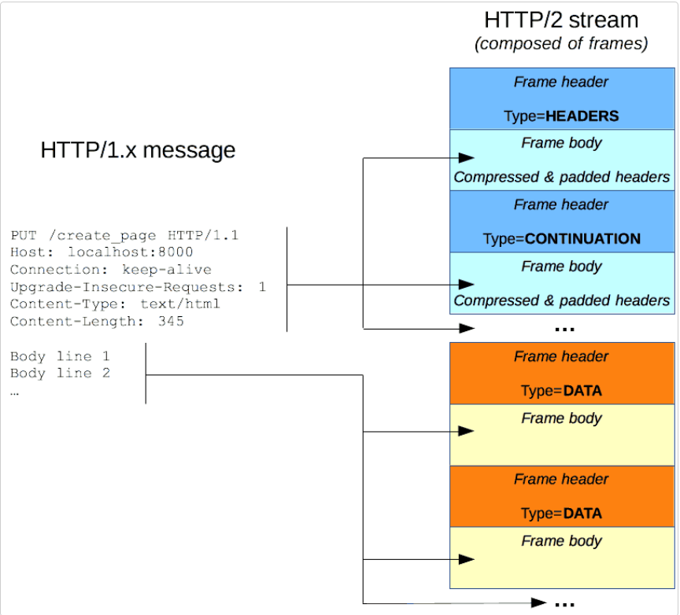

**Structure of HTTP Response:** HTTP Response has a special structure that is followed so that the client can easily understand it. HTTP Response broadly has 3 main components:

- Status Line
- Headers
- Body (Optional)

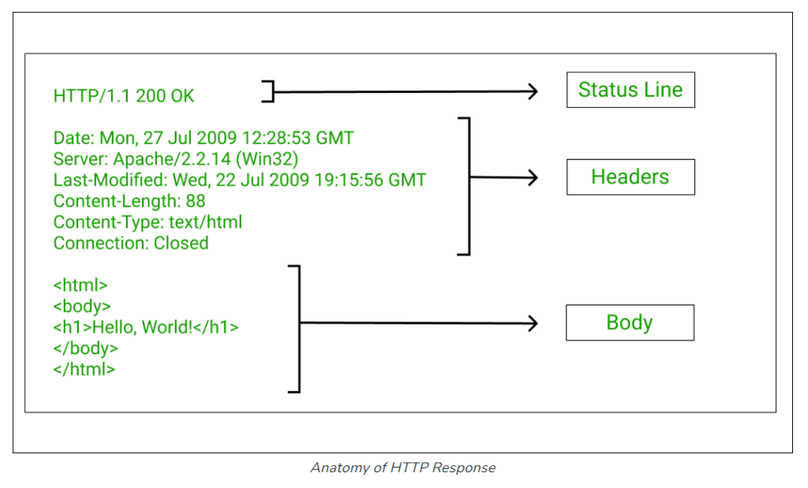

Let us go through each of them one by one:

**Status Line:** An example of a Status-Line is given below:

HTTP/1.1 200 OK

The Status Line contains three important components – HTTP Version, HTTP Response Code, and a Reason-Phrase.

- **HTTP Version:** The HTTP version number shows the HTTP specification to which the server has tried to make the response message comply. In the above example, **1.1** is the HTTP Version.
- **HTTP Response Code:** It is a 3 digit number that shows the conclusion of the Request. In the above example, the response code **200** denotes that the content requested was OK. A very popular Status Code that we frequently encounter is 404 which represents the requested resource was not found.
- **Reason-Phrase:** Also known as Status Text as it summarizes the Status Code in human-readable form.

**Response Header:** The Response Header contains the information about the content that is being returned in response together with data about the Server that sent it. This information helps the Client/Browser in deciding in what way the response data would be used. In other words, headers can be said as metadata that is sent together with a response to provide more info about it.

The Server can send as many headers as needed. The headers are sent as a key-value pair separated by a colon ( : ). Although the server can send as many headers as required, the most popular response headers are *Content-Length, Content-Type, Date, Server, Set-Cookie*, *etc.*

Date: Thu, 16 Jan 2016 08:16:18 GMT Server: IBM_CICS_Transaction_Server/3.1.0(zOS) Content-type: image/jpg

In the above example, the response header shows the date and time when the response was sent, the server that sent the response, and the type of content that was sent, which here is a jpg image file.

**Body:** In case of a successful response, the body of the Response Message is used to serve the Client/User with the resource asked for in the request. Although the body is optional, it is one of the most fundamental parts of the communication between the Client and Server and is sent most of the time. The body carries the data and can be in one of the many formats such as *json, html, image*, *etc.* which is accordingly specified in the headers.

In case of some errors, the body might provide the reason for the errors or the actions needed to complete the request successfully. Sometimes, it may have a link to guide the user to some other page.

## whois

**Goal of whois**

- Create a simple importable Python module which will produce parsed WHOIS data for a given domain.
- Able to extract data for all the popular TLDs (com, org, net, …)
- Query a WHOIS server directly instead of going through an intermediate web service like many others do.

**Installation and use**

`pip install python-whois`

Then use

`import whois`

```python
# You can do an install directly on Jupyter notebook
# By using '!' nefore the pip command
#!pip install python-whois
```

```python
import whois
print('Valid URL')
print(whois.whois('https://www.google.co.in/'))
print('Invalid URL')
print(whois.whois('xxxxxxxxxx.github.com'))
```

```
Valid URL
{
  "domain_name": "google.co.in",
  "registrar": "MarkMonitor Inc.",
  "registrar_url": "http://www.markmonitor.com",
  "registrar_iana": "292",
  "updated_date": "2023-05-27 10:02:07",
  "creation_date": "2003-06-23 14:02:33",
  "expiration_date": "2024-06-23 14:02:33",
  "name_servers": [
    "ns4.google.com",
    "ns2.google.com",
    "ns1.google.com",
    "ns3.google.com"
  ],
  "organization": "Google LLC",
  "state": "CA",
  "status": [
    "clientUpdateProhibited http://www.icann.org/epp#clientUpdateProhibited",
    "clientDeleteProhibited http://www.icann.org/epp#clientDeleteProhibited",
    "clientTransferProhibited http://www.icann.org/epp#clientTransferProhibited"
  ],
  "emails": null,
  "country": "US",
  "dnssec": "unsigned"
}
Invalid URL
{
  "domain_name": [
    "GITHUB.COM",
    "github.com"
  ],
  "registrar": "MarkMonitor, Inc.",
  "whois_server": "whois.markmonitor.com",
  "referral_url": null,
  "updated_date": "2022-09-07 09:10:44",
  "creation_date": "2007-10-09 18:20:50",
  "expiration_date": [
    "2024-10-09 18:20:50",
    "2024-10-09 00:00:00"
```

[output cut: 25 more lines]

```
    "clientDeleteProhibited (https://www.icann.org/epp#clientDeleteProhibited)"
  ],
  "emails": [
    "abusecomplaints@markmonitor.com",
    "whoisrequest@markmonitor.com"
  ],
  "dnssec": "unsigned",
  "name": null,
  "org": "GitHub, Inc.",
  "address": null,
  "city": null,
  "state": "CA",
  "zipcode": null,
  "country": "US"
}
```

**User-Agent header**

- The User-Agent header is one of many standard request headers.
- It identifies the request sender's device which includes information about the device type, operating system, browser name and version.
- Historically, the User-Agent was intended to help websites optimize served content for different devices.
- However, contemporary responsive websites mostly use this datapoint for tracking.
- The value of the user agent header is called **user agent string**.
- It follows a straightforward format that provides various details about the connecting user:

```
User-Agent: Mozilla/5.0 (<system-information>) <platform> <browser-info>
```

Let's break down this format:

- `Mozilla/5.0`: A historical artifact (always there).
- `<system-information>`: Represents the operating system, its version and the CPU architecture.
- `<platform>`: Represent the rendering engine used and its version.
- `<browser-info>`: Provides information about the used web browser and it's version.

**User Agent of my device is**

`Mozilla/5.0 (Windows NT 10.0; Win64; x64) AppleWebKit/537.36 (KHTML, like Gecko) Chrome/118.0.0.0 Safari/537.36`

## Finding the User Agent (UA) of your device using online service

[Online line for finding UA of your device](https://www.whatsmyua.info/)

## Finding the User Agent (UA) of your device

**1. Select More Tools > Developer tools**

[figure not shown]

**2. Select More Tools > Network Conditions**

[figure not shown]

**3.Uncheck Browser default**

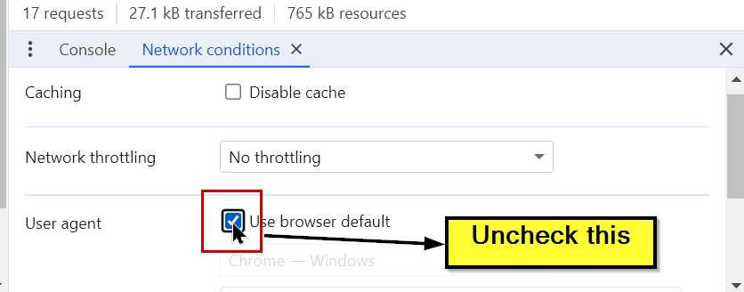

**4. Select appropriate device**

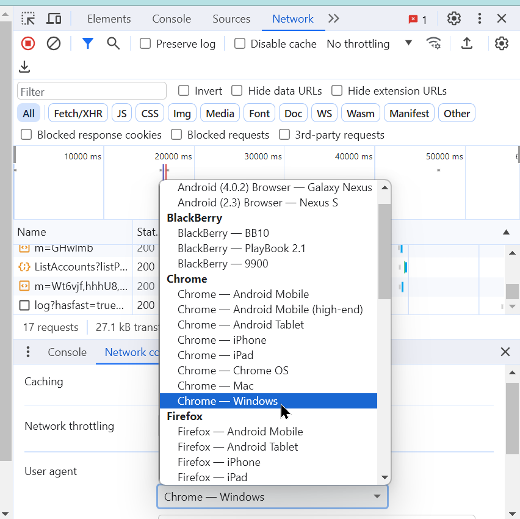

**5. User agent of Chrome Windows Browser**

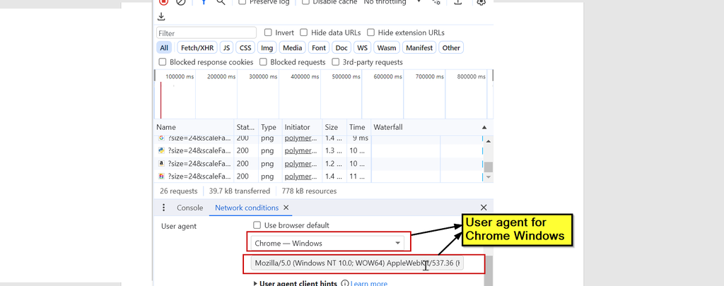

## Request and Response Objects

A request generally has some or all of the following four things:

1. URL ( Uniform Resource Locator): URL stands for Uniform or Universal Resource Locator. URLs are generally web addresses, but they could also refer to other resources like file transfer protocols (FTP) and database access. Headers:
2. Header provides some additional information about a request.
3. Method: In general there are four types of requests that a client may make to a server. These are:
   - GET—To request a server to get some resource.
   - POST—To request a server to create some new resource.
   - PUT—To request server to edit some resource.
   - DELETE—To request a server to delete some resource.
4. Body: The body of a request contains the data that the client wants to send to the server.

Note:-

- If you want to study source code of a Python file,
- it is a good idea to copy it from Github,
- paste in Notepad++ and
- then save the file in Notepad++ as a `.py` file

[Source code for `requests.api()` on GitHub](https://github.com/psf/requests/blob/333fa8d3f201f68b82d9e8f26be4987e869fd3bf/requests/api.py)

**Studying `requests.request()` [Not `Request` class]**

`requests.request(method, url, **kwargs)` [[source]](https://requests.readthedocs.io/en/latest/_modules/requests/api/#request)

Constructs and sends a [`Request`](https://requests.readthedocs.io/en/latest/api/#requests.Request). You can see the source code for the `requests.request()` method on GitHub [here](https://github.com/psf/requests/blob/839a8edec37c81a18ac8332cfbd44f44e1ae6206/src/requests/api.py#L14)

Parameters

- **method** – method for the new [`Request`](https://requests.readthedocs.io/en/latest/api/#requests.Request) object: `GET`, `OPTIONS`, `HEAD`, `POST`, `PUT`, `PATCH`, or `DELETE`. (**This parameter has to be given** )
- **url** – URL for the new [`Request`](https://requests.readthedocs.io/en/latest/api/#requests.Request) object. (**This parameter has to be given**)
- **params** – (optional) Dictionary, list of tuples or bytes to send in the query string for the [`Request`](https://requests.readthedocs.io/en/latest/api/#requests.Request).
- **data** – (optional) Dictionary, list of tuples, bytes, or file-like object to send in the body of the [`Request`](https://requests.readthedocs.io/en/latest/api/#requests.Request).
- **json** – (optional) A JSON serializable Python object to send in the body of the [`Request`](https://requests.readthedocs.io/en/latest/api/#requests.Request).
- **headers** – (optional) Dictionary of HTTP Headers to send with the [`Request`](https://requests.readthedocs.io/en/latest/api/#requests.Request).
- **cookies** – (optional) Dict or CookieJar object to send with the [`Request`](https://requests.readthedocs.io/en/latest/api/#requests.Request).
- **files** – (optional) Dictionary of `'name': file-like-objects` (or `{'name': file-tuple}`) for multipart encoding upload. `file-tuple` can be a 2-tuple `('filename', fileobj)`, 3-tuple `('filename', fileobj, 'content_type')` or a 4-tuple `('filename', fileobj, 'content_type', custom_headers)`, where `'content-type'` is a string defining the content type of the given file and `custom_headers` a dict-like object containing additional headers to add for the file.
- **auth** – (optional) Auth tuple to enable Basic/Digest/Custom HTTP Auth.
- **timeout** ([*float*](https://docs.python.org/3/library/functions.html#float) *or* [*tuple*](https://docs.python.org/3/library/stdtypes.html#tuple)) – (optional) How many seconds to wait for the server to send data before giving up, as a float, or a [(connect timeout, read timeout)](https://requests.readthedocs.io/en/latest/user/advanced/#timeouts) tuple.
- **allow_redirects** ([*bool*](https://docs.python.org/3/library/functions.html#bool)) – (optional) Boolean. Enable/disable GET/OPTIONS/POST/PUT/PATCH/DELETE/HEAD redirection. Defaults to `True`.
- **proxies** – (optional) Dictionary mapping protocol to the URL of the proxy.
- **verify** – (optional) Either a boolean, in which case it controls whether we verify the server’s TLS certificate, or a string, in which case it must be a path to a CA bundle to use. Defaults to `True`.
- **stream** – (optional) if `False`, the response content will be immediately downloaded.
- **cert** – (optional) if String, path to ssl client cert file (`.pem`). If Tuple, `(‘cert’, ‘key’)` pair.

Returns

[`Response`](https://requests.readthedocs.io/en/latest/api/#requests.Response) object

Return type

[`requests.Response`](https://requests.readthedocs.io/en/latest/api/#requests.Response)

[Response class source code on GitHub](https://github.com/psf/requests/blob/839a8edec37c81a18ac8332cfbd44f44e1ae6206/src/requests/models.py#L640)

**`requests.request()` method**

The signature of the requests.request() method is:  
`requests.request(method, url, **kwargs)` In the above signature, there are three items described in the following list:

- `Method`: This parameter is the 1st parameter. It could be of any of the seven types, i.e., `GET`, `OPTIONS`, `HEAD`, `POST`, `PUT`, `PATCH`and `DELETE`.
- `URL`: This parameter is the `URL` of the server to which the request is to be made.
- `**kwargs`: You know that in Python `**kwargs` stands for “key-value pair”. So this stands for the additional key-value pairs that you may want to give to your request object.
- Some common “keys” for `**kwarg` of request method are:
  - `data`: Suppose you want to send some data with your request, then you could add a key-value pair in form `data = some_data`, where `some_data` could be a dictionary, file like object, etc.
  - `headers`: You could send a “dictionary of headers” with this optional key
  - There are many other optional key-value pairs as part of `**kwarg` that you may send. They are not discussed but can be studied from the online documentation of the requests library.

Some other noteworthy points regarding the requests.request() method are:

- It is a “general method” and therefore can be used for “any of the 7 types” of requests.
- Note that the requests library also provides all these seven methods as separate methods. So for example you could make a request GET using
  - Either `requests.request(‘GET’, some_url)`,
  - Or you could make the same request using `requests.get(some_url)`

```python
import requests
# url of a text file at gutenberg taken
guten_url = 'http://www.gutenberg.org/files/98/98-h/98-h.htm'
resp_obj = requests.request(method = 'GET', url = guten_url)
# The Response object here is resp_obj
# It has a number of attributes
print('Encoding--->', resp_obj.encoding)
print('status_code--->', resp_obj.status_code)
print('url--->', resp_obj.url)
print('Cookies--->', resp_obj.cookies)
print('Time elapsed--->', resp_obj.elapsed)
print('headers--->', resp_obj.headers)
print('Links--->', resp_obj.links)
# Response object also has a text attribute of type string
print('Response object has attribute text of type--->',type(resp_obj.text))
print('Text--->', resp_obj.text[200:400])
```

```
Encoding---> ISO-8859-1
status_code---> 200
url---> https://www.gutenberg.org/files/98/98-h/98-h.htm
Cookies---> <RequestsCookieJar[]>
Time elapsed---> 0:00:01.042535
headers---> {'date': 'Mon, 23 Oct 2023 13:15:17 GMT', 'server': 'Apache', 'last-modified': 'Sat, 27 Mar 2021 07:23:16 GMT', 'accept-ranges': 'bytes', 'content-length': '988243', 'content-type': 'text/html'}
Links---> {}
Response object has attribute text of type---> <class 'str'>
Text---> equiv="Content-Type" content="text/html;charset=utf-8" />
<meta http-equiv="Content-Style-Type" content="text/css" />
<title>The Project Gutenberg EBook of A Tale of Two Cities, by Charles Dickens</
```

```python
import requests
r = requests.get('https://en.wikipedia.org/wiki/Python_(programming_language)')
print(type(r))

# Note r is a Response object,
# but it also has a .request attribute
# Which can give the original PreparedRequest Object sent to the server
print(r.request)
```

```
<class 'requests.models.Response'>
<PreparedRequest [GET]>
```

**Header and attributes of the Response object**

- We can get the headers of the `Respons`e object
- We can see all attributes of `Response` Object using Python built-in function `dir()`

```python
# We can get the headers of the Response object
#print(r.headers)
print('type(r.headers)---> ', type(r.headers))  # <class 'requests.structures.CaseInsensitiveDict'>
print('type(dict(r.headers))---> ', type(dict(r.headers)))  # So can cast to a dictionary
#print(r.headers)
# Check out the source code on GitHub to see all methods of Response Object
# We can see all attributes of Response Object using dir()
print(dir(r))
# Using the iter_lines() method
'''
for line in r.iter_lines():
    print('XXXXXXXXXX')
    print(line)
'''
```

```
type(r.headers)--->  <class 'requests.structures.CaseInsensitiveDict'>
type(dict(r.headers))--->  <class 'dict'>
['__attrs__', '__bool__', '__class__', '__delattr__', '__dict__', '__dir__', '__doc__', '__enter__', '__eq__', '__exit__', '__format__', '__ge__', '__getattribute__', '__getstate__', '__gt__', '__hash__', '__init__', '__init_subclass__', '__iter__', '__le__', '__lt__', '__module__', '__ne__', '__new…
```

```
"\nfor line in r.iter_lines():\n    print('XXXXXXXXXX')\n    print(line)\n"
```

**Wrapping request call in a `try-except` block**

- However in real life, whenever you write code for getting data from the net, you must take into account the possibilities of errors, and
- so must wrap your code in appropriate `try-except`blocks.
- Following is a script which includes an additional parameter for the `get()` function, i.e., `timeout=5`.
- The response object returned has a `status_code` property which will be `200` if all is ok.

```python
import requests
def func(url, timeL= 5):
    try:
        r = requests.get(url, timeout =timeL)
        if r.status_code != 200:
            print('problem')
            return None
        print('response code--->', r.status_code)
        return r
    except requests.exceptions.RequestException as e:
        print('Error---> ', e)
        print('Type of Error---> ', type(e))
        print('Something went wrong')
        return None

def checkPage(page):
    if type(page) == requests.models.Response:
        print('First 100 characters of response page--->')
        print(page.text[:100])
    else:
        print('page type is->', type(page))

#First call with default time limit 5
page1 = func('http://www.gutenberg.org/files/98/98-h/98-h.htm')
checkPage(page1)
#Second call with timeL .005, which is too short so will throw error
print('Second Call--->')
page2 = func('http://www.gutenberg.org/files/98/98-h/98-h.htm', 0.005)
checkPage(page2)
```

```
response code---> 200
First 100 characters of response page--->
<!DOCTYPE html PUBLIC "-//W3C//DTD XHTML 1.0 Strict//EN"
"http://www.w3.org/TR/xhtml1/DTD/xhtml1-st
Second Call--->
Error--->  HTTPConnectionPool(host='www.gutenberg.org', port=80): Max retries exceeded with url: /files/98/98-h/98-h.htm (Caused by ConnectTimeoutError(<urllib3.connection.HTTPConnection object at 0x0000017BAB64F190>, 'Connection to www.gutenberg.org timed out. (connect timeout=0.005)'))
Type of Error--->  <class 'requests.exceptions.ConnectTimeout'>
Something went wrong
page type is-> <class 'NoneType'>
```

**If you dont know the type of exception that may be thrown**

- But suppose you dont know the type of exception that may be thrown.
- You can still catch the exception using exception of class `Exception`.
- This is because in Python all exceptions inherit from `Exception`
- Then you can create an object `e` of this Exception class And use `type(e)` to get the type of the exception.
- This is shown in code below where the line of code

`except requests.exceptions.RequestException as e:`

is replaced by

`except Exception as e:`

```python
# But suppose you dont know the type of exception that may be thrown
# You can still catch the exception using exception of class Exception
# Then you can create an object e of this Exception class
# And use type(e) to get the type of the exception
# This is shown in code below where the line of code
# except requests.exceptions.RequestException as e:
# is replaced by
# except Exception as e:
import requests
def func(url, timeL= 5):
    try:
        r = requests.get(url, timeout =timeL)
        if r.status_code != 200:
            print('problem')
            return None
        print('response code--->', r.status_code)
        return r
    except Exception as e:
        print('Error---> ', e)
        print('Type of Error---> ', type(e))
        print('Something went wrong')
        return None

def checkPage(page):
    if type(page) == requests.models.Response:
        print('First 100 characters of response page--->')
        print(page.text[:100])
    else:
        print('page type is->', type(page))

#First call with default time limit 5
page1 = func('http://www.gutenberg.org/files/98/98-h/98-h.htm')
checkPage(page1)
#Second call with timeL .005, which is too short so will throw error
print('Second Call--->')
page2 = func('http://www.gutenberg.org/files/98/98-h/98-h.htm', 0.005)
checkPage(page2)
```

```
response code---> 200
First 100 characters of response page--->
<!DOCTYPE html PUBLIC "-//W3C//DTD XHTML 1.0 Strict//EN"
"http://www.w3.org/TR/xhtml1/DTD/xhtml1-st
Second Call--->
Error--->  HTTPConnectionPool(host='www.gutenberg.org', port=80): Max retries exceeded with url: /files/98/98-h/98-h.htm (Caused by ConnectTimeoutError(<urllib3.connection.HTTPConnection object at 0x0000017BAB454190>, 'Connection to www.gutenberg.org timed out. (connect timeout=0.005)'))
Type of Error--->  <class 'requests.exceptions.ConnectTimeout'>
Something went wrong
page type is-> <class 'NoneType'>
```

**The Response Object returned by the server also contains your original Request object**

- The `Response` object contains all of the information returned by the server and also contains the `Request` object you created originally.
- Whenever you receive a Response object from an API call or a `Session` call, the request attribute is actually the `PreparedRequest` that was used.
- This is shown in code below:-

```python
url2 = 'https://github.com/ag999git'
r2 = requests.request('GET', url = url2)
print(r2.request)
```

```
<PreparedRequest [GET]>
```

**Let us study the Request class**

Note that the Request class in the requests library is a lower level class. The Request class is used to prepare PreparedRequest class object which is sent to the server.

So

- the user first creates a [`Request`](https://requests.readthedocs.io/en/latest/api/#requests.Request) object.
- This Request object in turn is used to prepare a [`PreparedRequest`](https://requests.readthedocs.io/en/latest/api/#requests.PreparedRequest), which is sent to the server.

[Source code of Request class on GitHub](https://github.com/psf/requests/blob/333fa8d3f201f68b82d9e8f26be4987e869fd3bf/requests/models.py#L198)

[Source code for PreparedRequest class on GitHub](https://github.com/psf/requests/blob/333fa8d3f201f68b82d9e8f26be4987e869fd3bf/requests/models.py#L272)

**Docstring of Request class**

```
class Request(RequestHooksMixin):
"""
A user-created :class:`Request <Request>` object.
Used to prepare a :class:`PreparedRequest <PreparedRequest>`, which is sent to the server.
    :param method: HTTP method to use.
    :param url: URL to send.
    :param headers: dictionary of headers to send.
    :param files: dictionary of {filename: fileobject} files to multipart upload.
    :param data: the body to attach to the request. If a dictionary or
        list of tuples ``[(key, value)]`` is provided, form-encoding will
        take place.
    :param json: json for the body to attach to the request (if files or data is not specified).
    :param params: URL parameters to append to the URL. If a dictionary or
        list of tuples ``[(key, value)]`` is provided, form-encoding will
        take place.
    :param auth: Auth handler or (user, pass) tuple.
    :param cookies: dictionary or CookieJar of cookies to attach to this request.
    :param hooks: dictionary of callback hooks, for internal usage.

    Usage::

      >>> import requests
      >>> req = requests.Request('GET', 'https://httpbin.org/get')
      >>> req.prepare()
      <PreparedRequest [GET]>
    """
```

```python
# We can an object of class Request on our own also
import requests
req = requests.Request('GET', 'https://httpbin.org/get')

print('req--->', req)
print('req.prepare()--->', req.prepare())
print('dir(req)---> ', dir(req))
print('req.url---> ', req.url)
```

```
req---> <Request [GET]>
req.prepare()---> <PreparedRequest [GET]>
dir(req)--->  ['__class__', '__delattr__', '__dict__', '__dir__', '__doc__', '__eq__', '__format__', '__ge__', '__getattribute__', '__gt__', '__hash__', '__init__', '__init_subclass__', '__le__', '__lt__', '__module__', '__ne__', '__new__', '__reduce__', '__reduce_ex__', '__repr__', '__setattr__', '…
req.url--->  https://httpbin.org/get
```

**Docstring of PreparedRequest class**

class `PreparedRequest(RequestEncodingMixin, RequestHooksMixin)`: """The fully mutable :class:`PreparedRequest <PreparedRequest>` object, containing the exact bytes that will be sent to the server. Instances are generated from a :class:`Request <Request>` object, and **should not be instantiated manually**; doing so may produce undesirable effects.

```
Usage::

  >>> import requests
  >>> req = requests.Request('GET', 'https://httpbin.org/get')
  >>> r = req.prepare()
  >>> r
  <PreparedRequest [GET]>

  >>> s = requests.Session()
  >>> s.send(r)
  <Response [200]>
"""
```

**Let us create our own PreparedRequest Object**

The following code is taken (and modified) from [here.](https://requests.readthedocs.io/en/latest/user/advanced/#prepared-requests)

```python
# Let us create our own PreparedRequest Object
from requests import Request
url = 'https://en.wikipedia.org/wiki/Python_(programming_language)'
#req = Request('POST', url, data=data, headers=headers)
req = Request('POST', url)
prepped = req.prepare()

# do something with prepped.body
prepped.body = 'No, I want exactly this as the body.'
# do something with prepped.headers
print('prepped.body--->', prepped.body)
print('prepped.headers---> ', prepped.headers)
print('dir(prepped)---> ', dir(prepped))
```

```
prepped.body---> No, I want exactly this as the body.
prepped.headers--->  {'Content-Length': '0'}
dir(prepped)--->  ['__class__', '__delattr__', '__dict__', '__dir__', '__doc__', '__eq__', '__format__', '__ge__', '__getattribute__', '__gt__', '__hash__', '__init__', '__init_subclass__', '__le__', '__lt__', '__module__', '__ne__', '__new__', '__reduce__', '__reduce_ex__', '__repr__', '__setattr__…
```

**Problem of persistence of certain parameters across multiple `requests.get()` calls**

However, one problem with using `requests.get()` is that if the same website or server has to be called a number of times, then for each call, certain parameters will not persist. For example the code below shows that for each r`equests.get() call, a new cookie is generated:

```python
import requests
# First call
resp1 = requests.get('https://github.com/ag999git')
cookie1 = resp1.cookies
print('cookie1--->', cookie1)
# Second call
resp2 = requests.get('https://github.com/ag999git')
cookie2 = resp2.cookies
print('cookie2---> ', cookie2)
# Compare cookie1 and cookie2
print('Is cooki1 ==cookie2?--->', cookie1 == cookie2)
```

```
cookie1---> <RequestsCookieJar[<Cookie _octo=GH1.1.2068856023.1698066942 for .github.com/>, <Cookie logged_in=no for .github.com/>, <Cookie _gh_sess=zyXCTiJmkpwoNm2h4hhMHrazhSIwQRLtS6Hk%2Bx50%2FzvFfKbYUHnh0ntFOi0gxUGw74Cda6C3MkH8HLTzQwugj9jFezgpEiN%2Bv8v9B4%2F207zWCu41JXx9uSD8Rz5MwvZg3ab%2FE%2BVlof1…
cookie2--->  <RequestsCookieJar[<Cookie _octo=GH1.1.1966971007.1698066942 for .github.com/>, <Cookie logged_in=no for .github.com/>, <Cookie _gh_sess=YiLMnm8rb8eZk5H5%2Bi2KbtVfBsxuaYNmIVCRd6z40Ax3pod9v96yHjelto9d7uZ8OvTMDAqHM3lZIsLvksHWwuUSmtK4AYzVo39aAkLUPzwoxrQc2kPvG6WzQ89v4Cm77Cga%2B8yuXbk%2BRIOh…
Is cooki1 ==cookie2?---> False
```

**SSL Cert Verification** [Link](https://docs.python-requests.org/en/v1.1.0/user/advanced/#ssl-cert-verification)

**Session Objects** [Link to Advanced Usage](https://requests.readthedocs.io/en/latest/user/advanced/#session-objects)

- The Session object allows you to persist certain parameters across requests.
- It also persists cookies across all requests made from the Session instance, and will use `urllib3`’s [connection pooling](https://urllib3.readthedocs.io/en/latest/reference/index.html#module-urllib3.connectionpool).
- So if you’re making several requests to the same host, the underlying TCP connection will be reused, which can result in a significant performance increase (see [HTTP persistent connection on Wikipedia](https://en.wikipedia.org/wiki/HTTP_persistent_connection)).
- A Session object has all the methods of the main Requests API.
- Sessions can also be used to provide default data to the request methods. This is done by providing data to the properties on a session object.
- Any dictionaries that you pass to a request method will be merged with the session-level values that are set. The method-level parameters override session parameters.

**What is a SSL/TLS certificate?**

- SSL/TLS certificates allow web browsers to identify and establish encrypted network connections to websites using the Secure Sockets Layer/Transport Layer Security (SSL/TLS) protocol.
- Certificates are used within a cryptographic system known as a public key infrastructure (PKI).
- A certificate’s PKI allows one party to establish the identity of another party using certificates and trusting a third party known as a CA.
- An SSL certificate is a Digital certificate that can be used for authentication of a website, and it creates a secure connection between client and web server. When a certificate is installed it makes the website from HTTP to HTTPS

**What kind of data SSL certificate contains :**

- Domain name of website
- Sub-domains
- Issue date
- Expiration date
- SSL/TLS version
- Certificate authority information
- Public key
- Certificate signature algorithm

**SSL Cert Verification** [Link](https://docs.python-requests.org/en/v1.1.0/user/advanced/#ssl-cert-verification)

**Python Library certifi**

- Certifi provides Mozilla’s carefully curated collection of Root Certificates for validating the trustworthiness of SSL certificates while verifying the identity of TLS hosts.
- Requests uses certificates from the package [certifi](https://certifiio.readthedocs.io/).
- This allows for users to update their trusted certificates without changing the version of Requests.

You can install `certifi` using `pip` as shown:

```
$ pip install certifi
```

To reference the installed certificate authority (CA) bundle, you can use the built-in function:

```
import certifi
print(certifi.where())
```

```python
import certifi
print(certifi.where())
```

```
C:\ProgramData\Anaconda3\lib\site-packages\certifi\cacert.pem
```

**You can see contents of your cacert file**

```python
print(certifi.contents())
```

[output not shown]

[output cut: 4306 more lines]

[output not shown]

**HTTP response status codes**

HTTP response status codes indicate whether a specific HTTP request has been successfully completed. Responses are grouped in five classes:

1. [Informational responses](https://developer.mozilla.org/en-US/docs/Web/HTTP/Status#information_responses) (`100` – `199`)
2. [Successful responses](https://developer.mozilla.org/en-US/docs/Web/HTTP/Status#successful_responses) (`200` – `299`)
3. [Redirection messages](https://developer.mozilla.org/en-US/docs/Web/HTTP/Status#redirection_messages) (`300` – `399`)
4. [Client error responses](https://developer.mozilla.org/en-US/docs/Web/HTTP/Status#client_error_responses) (`400` – `499`)
5. [Server error responses](https://developer.mozilla.org/en-US/docs/Web/HTTP/Status#server_error_responses) (`500` – `599`)

[You can see all the status codes here](https://github.com/psf/requests/blob/main/src/requests/status_codes.py)

**Timeouts**

You can tell Requests to stop waiting for a response after a given number of seconds with the `timeout` parameter::

```
    >>> requests.get('http://github.com', timeout=0.001)
    Traceback (most recent call last):
      File "<stdin>", line 1, in <module>
    requests.exceptions.Timeout: HTTPConnectionPool(host='github.com', port=80): Request timed out. (timeout=0.001)
```

```
import requests
r = requests.get('https://api.github.com/events')
r.text
```

- Requests will automatically decode content from the server.
- Most unicode charsets are seamlessly decoded.
- When you make a request, Requests makes educated guesses about the encoding of the response based on the HTTP headers.
- The text encoding guessed by Requests is used when you access `r.text`.
- You can find out what encoding Requests is using, and change it, using the `r.encoding` property:

```
r.encoding  # 'utf-8'
r.encoding = 'ISO-8859-1' # Changes encoding to 'ISO-8859-1'
```

- If you change the encoding, Requests will use the new value of `r.encoding` whenever you call `r.text`.
- You might want to do this in any situation where you can apply special logic to work out what the encoding of the content will be.
- For example, HTML and XML have the ability to specify their encoding in their body.
- In situations like this, you should use `r.content`to find the encoding, and then set `r.encoding`.
- This will let you use `r.text` with the correct encoding.